# Tarea 7

## Parte 1

Resuelve el ejercicio 7.1.0.1 de las notas (sigue el ejemplo anterior a este ejercicio). Puedes utilizar nnet o el código con el que optimizamos en clase.

Este es el código para generar los datos:

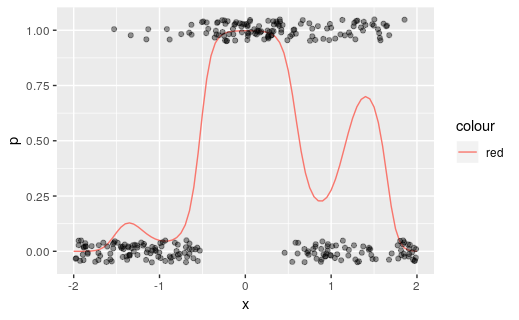

```r
library(tidyverse)
library(nnet)
h <- function(x){
  exp(x)/(1 + exp(x))
}
x <- seq(-2,2,0.05)
p <- h(3 + x- 3 * x ^ 2 + 3 * cos(4 * x))
set.seed(280572)
x.2 <- runif(300, -2, 2)
g.2 <- rbinom(300, 1, h(3 + x.2 - 3 * x.2 ^ 2 + 3 * cos(4 * x.2)))
datos <- data.frame(x.2,g.2)
dat.p <- data.frame(x,p)
g <- qplot(x,p, geom='line', col='red')
g + geom_jitter(data = datos, aes(x=x.2,y=g.2), col ='black',
                position =position_jitter(height=0.05), alpha=0.4)
```

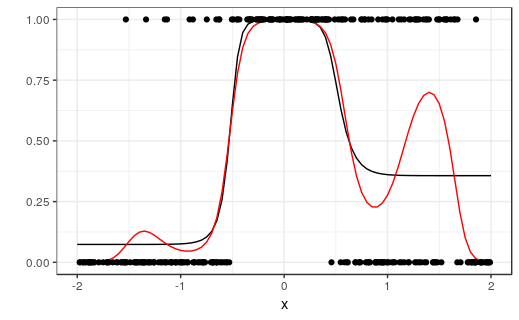

```r
# Tomamos dos neuronas en la capa oculta
nn     <- nnet(g.2~x.2, size=2, decay=0.001)
p.pred <- predict(nn, newdata=data.frame(x.2 = x))
neuronas2 <-mean((p-p.pred)^2)
ggplot()+theme_bw()+
  geom_line(aes(x, predict(nn, newdata=data.frame(x.2 = x))))+
  xlab("x")+
  geom_line( aes(x = x, y = p), col='red') +ylim(c(0,1))+
  geom_point(data = datos, aes(x = x.2, y = g.2))+
  ylab("")
```

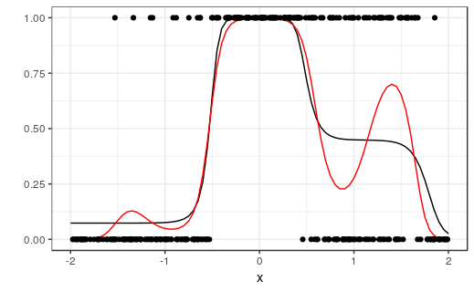

```r
# Tomamos tres neuronas en la capa oculta
nn     <-  nnet(g.2~x.2, size=3, decay=0.001)
p.pred <- predict(nn, newdata=data.frame(x.2 = x))
neuronas3 <- mean((p-p.pred)^2)
ggplot()+theme_bw()+
  geom_line(aes(x, predict(nn, newdata=data.frame(x.2 = x))))+
  xlab("x")+
  geom_line( aes(x = x, y = p), col='red') +ylim(c(0,1))+
  geom_point(data = datos, aes(x = x.2, y = g.2))+
  ylab("")
```

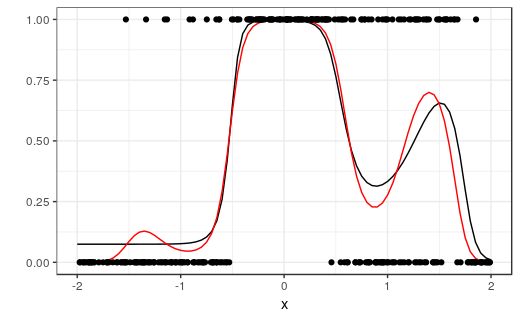

```r
# Tomamos 4 neuronas en la capa oculta
nn     <- nnet(g.2~x.2, size=4, decay=0.001)
p.pred <- predict(nn, newdata=data.frame(x.2 = x))
neuronas4 <- mean((p-p.pred)^2)
ggplot()+theme_bw()+
  geom_line(aes(x, predict(nn, newdata=data.frame(x.2 = x))))+
  xlab("x")+
  geom_line( aes(x = x, y = p), col='red') +ylim(c(0,1))+
  geom_point(data = datos, aes(x = x.2, y = g.2))+
  ylab("")
```

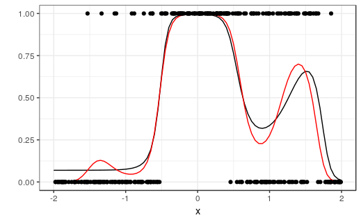

```r
# Tomamos 5 neuronas en la capa oculta
nn     <- nnet(g.2~x.2, size=5, decay=0.001)
p.pred <- predict(nn, newdata=data.frame(x.2 = x))
neuronas5 <- mean((p-p.pred)^2)
ggplot()+theme_bw()+
  geom_line(aes(x, predict(nn, newdata=data.frame(x.2 = x))))+
  xlab("x")+
  geom_line( aes(x = x, y = p), col='red') +ylim(c(0,1))+
  geom_point(data = datos, aes(x = x.2, y = g.2))+
  ylab("")
```

```r
c(neuronas2, neuronas3, neuronas4, neuronas5)
```

```
[1] 0.019110902 0.010148524 0.004440855 0.004455142
```

- ¿Qué tan bien puedes recuperar la forma verdadera (la función $p$, o la curva roja en la gráfica)?

No se logró capturar la curva inicial, la curva del centro se captura bastante bien, la curva final está, pero está desfasada.

- ¿Cuántas variables derivadas $a_k$ utilizaste? Intenta usar el mínimo posible. Utilizando 4 variables $a_k$ se logra capturar lo anterior, al agregar una quinta variable $a_k$ la forma de la función no mejora y empieza a alejarse de la curva verdadera.
- A grandes rasgos, ¿Puedes capturar todos los movimientos de la función verdadera $p$ con esta muestra de entrenamiento? Explica por qué si puedes o por qué no.

No, por que no hay suficientes datos que logren jalar la primera curva hacia arriba.

## Parte 2

1. Instala el paquete keras de R en tu computadora. Sigue [estas instrucciones](https://keras.rstudio.com).
2. **Si no funciona el método de arriba en tu computadora** (generalmente por instalaciones de python diferentes, etc), puedes instalar en un contenedor de docker.

Primero instala [docker](https://www.docker.com/get-started) en tu computadora. Baja el archivo Dockerfile del repositorio (se tiene que llamar Dockerfile, sin extensión). En línea de comandos, en el mismo directorio donde está el Dockerfile, corre las siguiente línea:

```
docker build -t aprendizaje-rstudio .
```

Esto va a tomar varios minutos, pero solo hay que correrlo una vez.

Después, cuando quieras usar el contenedor, corre:

```
docker run --rm -p 8787:8787 -e PASSWORD=tupassword -v ~/tu/carpeta/local:/home/rstudio/ aprendizaje-rstudio
```

Nota: en windows la segunda línea debe ser de la forma:

```
docker run --rm -p 8787:8787 -e PASSWORD=tupassword -v /c/Users/miusuario/micarpeta:/home/rstudio/ aprendizaje-rstudio
```

Y abre en Chrome o Safari (o el navegador que uses) la dirección:

http://localhost:8787

Y ahora puedes trabajar en rstudio dentro del contenedor de docker (user: rstudio, password: tupassword).

3. Corre algún ejemplo para checar tu instalación, por ejemplo:

https://keras.rstudio.com/articles/tutorial_basic_regression.html

```r
library(keras)
mnist <- dataset_mnist()
x_train <- mnist$train$x
y_train <- mnist$train$y
x_test <- mnist$test$x
y_test <- mnist$test$y
```

```r
# reshape
x_train <- array_reshape(x_train, c(nrow(x_train), 784))
x_test <- array_reshape(x_test, c(nrow(x_test), 784))
# rescale
x_train <- x_train / 255
x_test <- x_test / 255
```

```r
y_train <- to_categorical(y_train, 10)
y_test <- to_categorical(y_test, 10)
```

```r
model <- keras_model_sequential()
model %>%
  layer_dense(units = 256, activation = 'relu', input_shape = c(784)) %>%
  layer_dropout(rate = 0.4) %>%
  layer_dense(units = 128, activation = 'relu') %>%
  layer_dropout(rate = 0.3) %>%
  layer_dense(units = 10, activation = 'softmax')
```

```r
summary(model)
```

```
______________________________________________________________________
Layer (type)                   Output Shape                Param #
======================================================================
dense_19 (Dense)               (None, 256)                 200960
______________________________________________________________________
dropout_3 (Dropout)            (None, 256)                 0
______________________________________________________________________
dense_20 (Dense)               (None, 128)                 32896
______________________________________________________________________
dropout_4 (Dropout)            (None, 128)                 0
______________________________________________________________________
dense_21 (Dense)               (None, 10)                  1290
======================================================================
Total params: 235,146
Trainable params: 235,146
Non-trainable params: 0
______________________________________________________________________
```

```r
model %>% compile(
  loss = 'categorical_crossentropy',
  optimizer = optimizer_rmsprop(),
  metrics = c('accuracy')
)
```

```r
history <- model %>% fit(
  x_train, y_train,
  epochs = 30, batch_size = 128,
  validation_split = 0.2
)
```

```
Train on 48000 samples, validate on 12000 samples
```

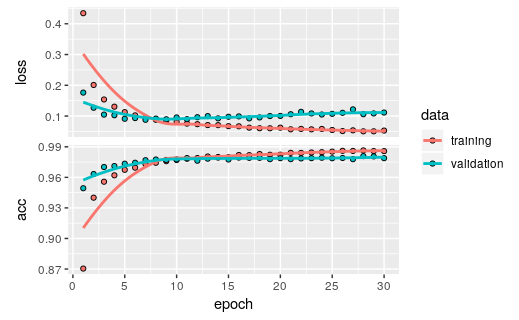

```r
plot(history)
```

```r
model %>% evaluate(x_test, y_test)
```

```
$loss
[1] 0.1033599

$acc
[1] 0.9814
```

```r
model %>% predict_classes(x_test)
```

[output not shown]

[output cut: 18 more lines]